# What Drives Contribution at FamilySearch?

- Show All Code
- Hide All Code

A Behavioral Lens on New Users - A Case Study

Author

Felix Jena

## Libraries Used, Dataset, and Tasks

```r
pacman::p_load(tidyverse, lubridate, janitor, DT, pander, plotly, scales)

# Loading in dataset
fs_data <- read_csv("C:/Users/felix/OneDrive/Documents/Family Search BI Analyst Interview/April_2025_Case_Study_Data.csv") %>%
  clean_names() %>%
  mutate(across(contains("_date"), ymd))
```

## Executive Summary

This case study explores how new users interact with FamilySearch’s core features and redefines user segments based on depth and type of engagement. We segmented users into **four behavior-based profiles** based on what they actually did inside the platform - from browsing to building.

By rethinking our segmentation model, we gain sharper insight into where users thrive, where they stall, and how we might turn intention into lasting contribution.

## Engagement Snapshot

```r
engagement_summary <- fs_data %>%
  select(
    total_days_logging_in,
    total_days_viewing_records,
    total_days_adding_names_to_tree,
    names_added_to_tree,
    total_days_editing_tree,
    total_days_uploading_memories,
    memories_uploaded,
    total_days_attaching_sources_to_tree,
    sources_attached_to_tree,
    total_days_using_get_involved
  ) %>%
  summary()

pander(engagement_summary, caption = "Engagement Activity Summary Across Key Features")
```

Engagement Activity Summary Across Key Features (continued below)

| total_days_logging_in | total_days_viewing_records |
| --- | --- |
| Min. : 0.000 | Min. : 0.0000 |
| 1st Qu.: 1.000 | 1st Qu.: 0.0000 |
| Median : 1.000 | Median : 0.0000 |
| Mean : 2.594 | Mean : 0.7469 |
| 3rd Qu.: 2.000 | 3rd Qu.: 1.0000 |
| Max. :272.000 | Max. :254.0000 |

Table continues below

| total_days_adding_names_to_tree | names_added_to_tree |
| --- | --- |
| Min. : 0.0000 | Min. : 0.000 |
| 1st Qu.: 0.0000 | 1st Qu.: 0.000 |
| Median : 1.0000 | Median : 2.000 |
| Mean : 0.7737 | Mean : 4.571 |
| 3rd Qu.: 1.0000 | 3rd Qu.: 5.000 |
| Max. :255.0000 | Max. :25432.000 |

Table continues below

| total_days_editing_tree | total_days_uploading_memories | memories_uploaded |
| --- | --- | --- |
| Min. : 0.0000 | Min. : 0.00000 | Min. : 0.000 |
| 1st Qu.: 0.0000 | 1st Qu.: 0.00000 | 1st Qu.: 0.000 |
| Median : 0.0000 | Median : 0.00000 | Median : 0.000 |
| Mean : 0.7738 | Mean : 0.05084 | Mean : 0.246 |
| 3rd Qu.: 1.0000 | 3rd Qu.: 0.00000 | 3rd Qu.: 0.000 |
| Max. :262.0000 | Max. :166.00000 | Max. :5813.000 |

Table continues below

| total_days_attaching_sources_to_tree | sources_attached_to_tree |
| --- | --- |
| Min. : 0.0000 | Min. : 0.00 |
| 1st Qu.: 0.0000 | 1st Qu.: 0.00 |
| Median : 0.0000 | Median : 0.00 |
| Mean : 0.1961 | Mean : 7.47 |
| 3rd Qu.: 0.0000 | 3rd Qu.: 0.00 |
| Max. :255.0000 | Max. :235901.00 |

| total_days_using_get_involved |
| --- |
| Min. : 0.00000 |
| 1st Qu.: 0.00000 |
| Median : 0.00000 |
| Mean : 0.01648 |
| 3rd Qu.: 0.00000 |
| Max. :176.00000 |

```r
na_counts <- fs_data %>%
  summarise(across(contains("_date"), ~ sum(is.na(.)))) %>%
  pivot_longer(everything(), names_to = "Column", values_to = "Missing_Count")

datatable(
  na_counts,
  caption = "Missing Values in Key Engagement Dates",
  options = list(pageLength = 5)
)
```

|  | Column | Missing_Count |
| --- | --- | --- |
| 1 | account_create_date | 0 |
| 2 | earliest_login_date | 215576 |
| 3 | latest_login_date | 3399369 |
| 4 | earliest_record_viewing_date | 2217692 |
| 5 | latest_record_viewing_date | 2217692 |
| 6 | earliest_adding_names_to_tree_date | 1461088 |
| 7 | latest_adding_names_to_tree_date | 1461088 |
| 8 | earliest_tree_editing_date | 1772975 |
| 9 | latest_tree_editing_date | 1772975 |
| 10 | earliest_memory_upload_date | 3302346 |

[output cut: 5 more lines]

## Behavior-Based Segments

```r
fs_data <- fs_data %>%
  mutate(
    creator = names_added_to_tree > 0 | total_days_editing_tree > 0,
    browser_only = total_days_logging_in > 0 & names_added_to_tree == 0 & total_days_editing_tree == 0,
    dormant = total_days_logging_in == 0,
    memory_uploader = memories_uploaded > 0,
    researcher = sources_attached_to_tree > 0,
    behavior_segment = case_when(
      dormant ~ "Dormant",
      creator & memory_uploader & researcher ~ "Power User",
      creator ~ "Creator",
      browser_only ~ "Browser Only",
      memory_uploader | researcher ~ "Supportive Contributor",
      TRUE ~ "Unclassified"
    )
  )
```

We categorized users into **four behavioral segments** to reflect how they engage with FamilySearch. Power Users are highly active, using at least three core features like adding names, editing trees, uploading memories, or attaching sources. Creators contribute by adding names to the tree but use fewer advanced features. Browser Only users explore the site (logins, record views) without making contributions. Dormant users registered but never engaged. These segments help us understand where users drop off, who drives value, and where we can focus efforts to guide behavior and boost retention.

```r
segment_distribution <- fs_data %>%
  count(behavior_segment, sort = TRUE)

plot_ly(segment_distribution,
        x = ~n,
        y = ~behavior_segment,
        type = "bar",
        orientation = "h",
        text = ~scales::comma(n),
        textposition = "auto",
        marker = list(color = "mediumseagreen")) %>%
  layout(title = "User Distribution by Behavior Segment",
         xaxis = list(title = ""),
         yaxis = list(title = "
                      "))
```

[interactive chart not shown]

## Segment vs. Age Group

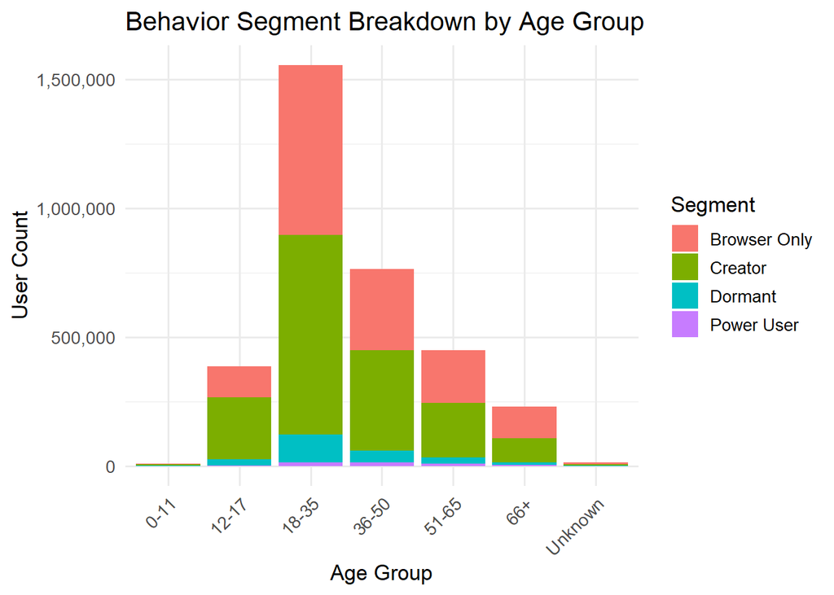

```r
age_seg_summary <- fs_data %>%
  count(age_group, behavior_segment) %>%
  drop_na() %>%
  ggplot(aes(x = age_group, y = n, fill = behavior_segment)) +
  geom_col(position = "stack") +
  scale_y_continuous(labels = comma) +
  labs(
    title = "Behavior Segment Breakdown by Age Group",
    x = "Age Group", y = "User Count", fill = "Segment"
  ) +
  theme_minimal(base_size = 13) +
  theme(axis.text.x = element_text(angle = 45, hjust = 1))

age_seg_summary
```

> **Insight:** The 18–35 age group is driving most platform activity, including Creator and Power User roles. But Browser-Only users are present across all age groups - especially 50+. These users may benefit from simplified interfaces and value-focused onboarding.

## Top Countries by User Count

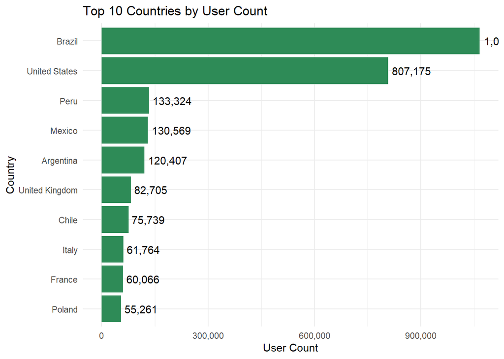

```r
country_counts <- fs_data %>%
  count(country, sort = TRUE) %>%
  slice_max(order_by = n, n = 10)

ggplot(country_counts, aes(x = reorder(country, n), y = n)) +
  geom_col(fill = "seagreen") +
  geom_text(aes(label = scales::comma(n)), hjust = -0.1) +
  coord_flip() +
  scale_y_continuous(labels = scales::comma) +
  labs(title = "Top 10 Countries by User Count",
       x = "Country", y = "User Count") +
  theme_minimal()
```

> **Insight:** Brazil and the U.S. are your largest user bases. Tailor re-engagement and onboarding flows in those countries first - they offer the most leverage.

## Segment Breakdown by Country

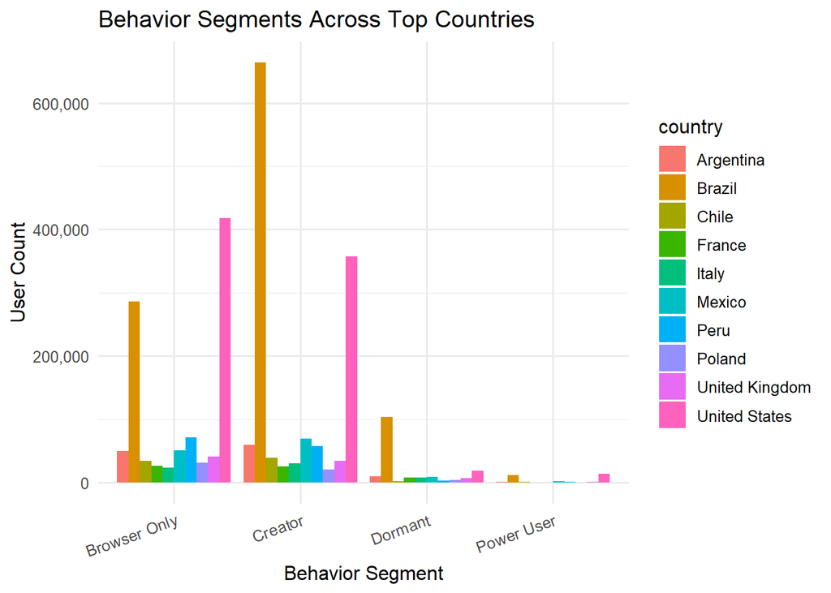

```r
top_country_names <- country_counts$country

country_seg <- fs_data %>%
  filter(country %in% top_country_names) %>%
  count(country, behavior_segment)

ggplot(country_seg, aes(x = behavior_segment, y = n, fill = country)) +
  geom_col(position = "dodge") +
  scale_y_continuous(labels = comma) +
  labs(title = "Behavior Segments Across Top Countries",
       x = "Behavior Segment", y = "User Count") +
  theme_minimal(base_size = 12) +
  theme(axis.text.x = element_text(angle = 20, hjust = 1))
```

> **Insight:** Power Users cluster heavily in Brazil and the U.S. Localization matters here - even small regional adaptations may turn “Creators” into “Champions.”

## Recommendations

### 1. Activate Dormants with Personalized Nudges

- Prompt dormant users 3–5 days post sign-up with quick-start actions.
- Use messaging like: “Just 1 name can start your family story.”

### 2. Guide Browsers to First Contribution

- Trigger a soft CTA: “Click here to validate a fact.”
- Offer mobile-first suggestions or 1-click tips.

### 3. Celebrate Supportive Contributors

- Highlight users who uploaded photos or linked sources.
- Reward their effort - even if they didn’t build trees.

### 4. Spotlight Power Users

- Offer badges, contributor stats, or “monthly spotlight.”
- Invite them to beta test new features.

### 5. Age-Sensitive Design

- 18–35: Quick, mobile-first, gamified tasks.
- 50+: Clear, accessible walkthroughs with legacy framing.